# Reducción de dimensiones con conservación de la probabilidad conjunta en bases de datos mixtas agrupadas, estratificadas y con mecanismos de pérdida MNAR mediante el método MIRIMFA

# Métricas de Evaluación

Para medir el desempeño de MIRIMFA, utilizaremos las siguientes métricas:

# Resultados

Los valores del coeficiente $R_V$ ajustado para cada porcentaje de datos faltantes se representan en la figura siguiente, comparados con los RIMFAs que los componen.

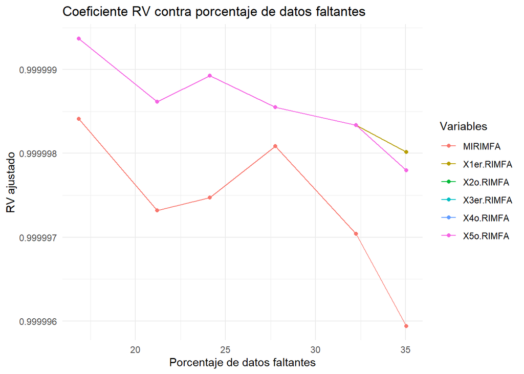

Coeficiente RV contra porcentaje de datos faltantes comparando resultados de MIRIMFA y las imputaciones individuales que lo conforman.

El análisis de los compromisos revela una alta similitud entre las configuraciones factoriales obtenidas a partir de las imputaciones individuales, lo cual se refleja en valores elevados del coeficiente RV ajustado. Esta concordancia sugiere que el procedimiento de imputación no introduce distorsiones significativas en la estructura multivariada de los datos.

Es posible que la pequeña reducción de ajuste de MIRIMFA con respecto a RIMFA se deba a la poca cantidad de imputaciones y a la elección arbitraria de $\mathbf{r}$, que debería de ser evaluada más conciensudamente. Sin embargo, el hecho de que estos dos efectos sean arbitrarios y no tengan impacto significativo en el ajuste sugiere que MIRIMFA es un método robusto.

# Discusión

Los resultados obtenidos ponen de manifiesto la robustez del Análisis Factorial Múltiple cuando se combina con estrategias de imputación para el tratamiento de datos faltantes. La elevada concordancia entre las configuraciones factoriales sugiere que la información esencial del sistema multivariado se conserva, incluso en presencia de incertidumbre asociada a la imputación.

El uso del compromiso permite sintetizar de manera eficiente la variabilidad entre imputaciones, proporcionando una representación estable y fácilmente interpretable de los datos. Esta propiedad resulta especialmente valiosa en contextos aplicados, donde la reproducibilidad y la estabilidad de los resultados son aspectos clave.

En comparación con enfoques que analizan cada imputación de forma aislada, la estrategia adoptada en este trabajo ofrece una visión integrada que facilita la interpretación global sin sacrificar rigor estadístico.

# Conclusión.

Los resultados muestran que esta aproximación permite obtener representaciones estables y coherentes, preservando la estructura subyacente de los datos.

La metodología propuesta constituye una herramienta flexible para el análisis multivariado en presencia de datos incompletos, y puede extenderse a contextos donde coexistan variables de distinta naturaleza. Como líneas futuras de investigación, se podría explorar la aplicación del enfoque a conjuntos de datos de mayor complejidad.

Queda pendiente investigar métodos adecuados de asignación de los pesos $\mathbf{r}$ para pérdidas MNAR-SS con desplazamiento, así como buscar métodos computacionales eficientes para aplicar MIRIMFA, ya que, tal como fue implementado en este trabajo, es un método muy demandante en poder de cómputo.

# Referencias

Hippel, Paul T. von. 2018. *How Many Imputations Do You Need? A Two-Stage Calculation Using a Quadratic Rule*. https://arxiv.org/abs/1608.05406.

Husson, François, and Julie Josse. 2013. “Handling Missing Values in Multiple Factor Analysis.” *Food Quality and Preference* 30 (2): 77–85.

Jackson, James, Robin Mitra, Niels Hagenbuch, Sarah McGough, and Chris Harbron. 2023. “A Complete Characterisation of Structured Missingness.” *arXiv Preprint arXiv:2307.02650*.

Josse, Julie, and François Husson. 2012. “Handling Missing Values in Exploratory Multivariate Data Analysis Methods.” *Journal de La Société Française de Statistique* 153 (2): 79–99.

Josse, Julie, and François Husson. 2016. “missMDA: A Package for Handling Missing Values in Multivariate Data Analysis.” *Journal of Statistical Software* 70 (1): 1–31. https://doi.org/10.18637/jss.v070.i01.

Lê, Sébastien, Julie Josse, and François Husson. 2008. “FactoMineR: A Package for Multivariate Analysis.” *Journal of Statistical Software* 25 (1): 1–18. https://doi.org/10.18637/jss.v025.i01.

Pagès, Jérôme. 2002. “Analyse Factorielle Multiple Appliquée Aux Variables Qualitatives Et Aux Données Mixtes.” *Revue de Statistique Appliquée* 50 (4): 5–37.

Rubin, Donald B. 1976. “Inference and Missing Data.” *Biometrika* 63 (3): 581–92.

Rubin, Donald B. 2004. *Multiple Imputation for Nonresponse in Surveys*. Vol. 81. John Wiley & Sons.

Van Buuren, Stef. 2018. *Flexible Imputation of Missing Data*. CRC press.

Van der Heijden, PGM, B Escofier, et al. 2003. “Multiple Correspondence Analysis with Missing Data.” *Analyse Des Correspondances. Recherches Sur l’analyse Des Correspondances*, 152–70.

Voillet, Valentin, Philippe Besse, Laurence Liaubet, Magali San Cristobal, and Ignacio González. 2016. “Handling Missing Rows in Multi-Omics Data Integration: Multiple Imputation in Multiple Factor Analysis Framework.” *BMC Bioinformatics* 17: 1–16.